# A quick and dirty intro to stats in R

Helms Cahan & Lockwood Lab Meeting

TS O’Leary

April 5, 2021

# **Disclaimer!**

Quick! Leave while you can! I don’t know stats! But other people sure do! And the internet is full of those people – and they seem like a helpful and kind bunch.

Here are some links that will be of more use to you:

## General R intro links

- [R for data science](https://r4ds.had.co.nz/index.html) – a wonderfully thorough and useful book that emphasizes the tidyverse
- [R for Graduate Students](https://bookdown.org/yih_huynh/Guide-to-R-Book/) – very accessible introduction to R & the tidyverse

## Stats links

- [Learning Statistics with R](https://learningstatisticswithr.com/book/) – there is also a [newer version](http://tidylsr.djnavarro.net/index.html) that is in development that emphasizes the tidyverse.
- [`survminer` vignette](https://rpkgs.datanovia.com/survminer/) – survival curves in R
- [Game of Thrones survival](https://carpentries-incubator.github.io/r-survival-analysis/aio/index.html)
- [More survival in R](https://www.emilyzabor.com/tutorials/survival_analysis_in_r_tutorial.html)
- [ANOVA in R](https://statsandr.com/blog/anova-in-r/#introduction) – stats for multi-factor experimental design

## Data visualization

- [The Fundamentals of Data Visualization](https://clauswilke.com/dataviz/) – great book on data viz
- [`ggplot2` book](https://ggplot2-book.org/) – detailed intro to plotting with ggplot

You have been warned that there are better resources out there. Continue at your own risk.

# **Tom’s stolen & unsolicited advice**

1. **Stand on the shoulders of giants.** If Issac Newton did it, then it ain’t cheating. Other people have probably tried something close to what you are about to do. Find it. Use it. Build on it.
2. **Move fast and break things.** While perhaps a terrible motto for one of the most powerful companies ever created on this planet, it’s not bad advice for coding. Just try stuff out. See what works. See what doesn’t. Make it your own. Break it. Move on and try something else.
3. **If you can dream it. You can do it.** Walt Disney – or at least some guy that worked in marketing for Walt Disney’s company after he died – whatever… who cares? either way… Be creative. Think up your dream data analysis and visualization and make it happen. Sketch it out, erase it, and turn it into Mickey Mouse.
4. **Whatever you do, do it with intention.** Embroidered throw pillow in my aunt’s beach house. Think about your decisions and have a reason for each choice. Why this statistical analysis? Why this line of code? Why use this argument in this function? Why this package? Why this visualization? Why this color? Why this theme? Have an answer. Make deliberate choices.

# **Stats in R**

I like to use the `tidyverse` for everything. Check out [this intro](https://tsoleary.github.io/play/Lockwood_Lab/tidyverse_intro.html) that I made for the Lockwood Lab meeting, which also has a bunch of more helpful links to people smarter than me and they’ll make you love R.

```r
# Load library
require(tidyverse)
```

# **Statistics for multi-factor experimental design**

```r
ToothGrowth %>%
  as_tibble()
```

```
# A tibble: 60 × 3
     len supp   dose
   <dbl> <fct> <dbl>
 1   4.2 VC      0.5
 2  11.5 VC      0.5
 3   7.3 VC      0.5
 4   5.8 VC      0.5
 5   6.4 VC      0.5
 6  10   VC      0.5
 7  11.2 VC      0.5
 8  11.2 VC      0.5
 9   5.2 VC      0.5
10   7   VC      0.5
# … with 50 more rows
```

```r
ToothGrowth %>%
  group_by(supp, dose) %>%
  tally()
```

```
# A tibble: 6 × 3
# Groups:   supp [2]
  supp   dose     n
  <fct> <dbl> <int>
1 OJ      0.5    10
2 OJ      1      10
3 OJ      2      10
4 VC      0.5    10
5 VC      1      10
6 VC      2      10
```

## Visualize data

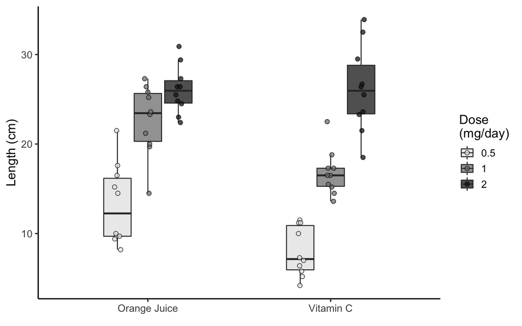

```r
ToothGrowth %>%
  mutate(dose = as.factor(dose)) %>%
  ggplot(aes(x = supp,
             y = len,
             fill = dose),
         color = "grey20") +
  geom_boxplot(alpha = 0.75,
               outlier.shape = NA,
               width = 0.5) +
  geom_point(shape = 21,
             alpha = 0.75,
             size = 2,
             position = position_jitterdodge(jitter.width = 0.1,
                                             dodge.width = 0.5)) +
  scale_x_discrete(name = element_blank(),
                   labels = c("Orange Juice", "Vitamin C")) +
  scale_y_continuous(name = "Length (cm)",
                     breaks = c(0,10,20,30)) +
  scale_fill_manual(name = "Dose\n(mg/day)",
                    values = c("grey90", "grey50", "grey10")) +
  theme_classic(base_size = 14)
```

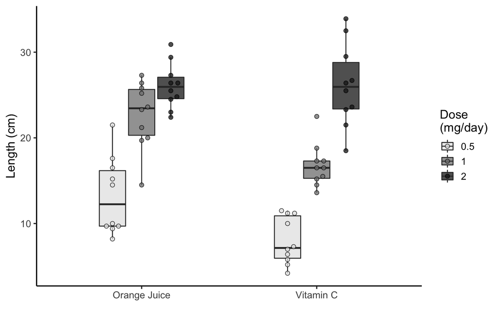

```r
ToothGrowth %>%
  mutate(dose = as.factor(dose)) %>%
  ggplot(aes(x = supp,
             y = len,
             fill = dose),
         color = "grey20") +
  geom_boxplot(alpha = 0.75,
               outlier.shape = NA,
               width = 0.5) +
  ggbeeswarm::geom_beeswarm(shape = 21,
             alpha = 0.75,
             size = 2,
             dodge.width = 0.5,
             cex = 2) +
  scale_x_discrete(name = element_blank(),
                   labels = c("Orange Juice", "Vitamin C")) +
  scale_y_continuous(name = "Length (cm)",
                     breaks = c(0,10,20,30)) +
  scale_fill_manual(name = "Dose\n(mg/day)",
                    values = c("grey90", "grey50", "grey10")) +
  theme_classic(base_size = 14)
```

## Testing assumptions

Check out [this webpage](https://cran.r-project.org/web/packages/afex/vignettes/assumptions_of_ANOVAs.html) on testing the assumptions of ANOVAs.

## Two-way ANOVA

```r
mod <- aov(len ~ supp + dose + supp:dose,
           data = ToothGrowth %>%
             mutate(dose = as.factor(dose)))

summary(mod)
```

```
            Df Sum Sq Mean Sq F value   Pr(>F)
supp         1  205.4   205.4  15.572 0.000231 ***
dose         2 2426.4  1213.2  92.000  < 2e-16 ***
supp:dose    2  108.3    54.2   4.107 0.021860 *
Residuals   54  712.1    13.2
---
Signif. codes:  0 '***' 0.001 '**' 0.01 '*' 0.05 '.' 0.1 ' ' 1
```

## **Post-hoc tests**

```r
mod_tukey <- TukeyHSD(mod)

mod_tukey
```

```
  Tukey multiple comparisons of means
    95% family-wise confidence level

Fit: aov(formula = len ~ supp + dose + supp:dose, data = ToothGrowth %>% mutate(dose = as.factor(dose)))

$supp
      diff       lwr       upr     p adj
VC-OJ -3.7 -5.579828 -1.820172 0.0002312

$dose
        diff       lwr       upr   p adj
1-0.5  9.130  6.362488 11.897512 0.0e+00
2-0.5 15.495 12.727488 18.262512 0.0e+00
2-1    6.365  3.597488  9.132512 2.7e-06

$`supp:dose`
               diff        lwr        upr     p adj
VC:0.5-OJ:0.5 -5.25 -10.048124 -0.4518762 0.0242521
OJ:1-OJ:0.5    9.47   4.671876 14.2681238 0.0000046
VC:1-OJ:0.5    3.54  -1.258124  8.3381238 0.2640208
OJ:2-OJ:0.5   12.83   8.031876 17.6281238 0.0000000
VC:2-OJ:0.5   12.91   8.111876 17.7081238 0.0000000
OJ:1-VC:0.5   14.72   9.921876 19.5181238 0.0000000
VC:1-VC:0.5    8.79   3.991876 13.5881238 0.0000210
OJ:2-VC:0.5   18.08  13.281876 22.8781238 0.0000000
VC:2-VC:0.5   18.16  13.361876 22.9581238 0.0000000
VC:1-OJ:1     -5.93 -10.728124 -1.1318762 0.0073930
OJ:2-OJ:1      3.36  -1.438124  8.1581238 0.3187361
VC:2-OJ:1      3.44  -1.358124  8.2381238 0.2936430
OJ:2-VC:1      9.29   4.491876 14.0881238 0.0000069
VC:2-VC:1      9.37   4.571876 14.1681238 0.0000058
VC:2-OJ:2      0.08  -4.718124  4.8781238 1.0000000
```

```r
mod_tukey$`supp:dose` %>%
  as_tibble(rownames = "comp") %>%
  filter(`p adj` < 0.01) %>%
  arrange(`p adj`)
```

```
# A tibble: 10 × 5
   comp         diff    lwr   upr  `p adj`
   <chr>       <dbl>  <dbl> <dbl>    <dbl>
 1 VC:2-VC:0.5 18.2   13.4  23.0  4.82e-13
 2 OJ:2-VC:0.5 18.1   13.3  22.9  4.86e-13
 3 OJ:1-VC:0.5 14.7    9.92 19.5  2.99e-11
 4 VC:2-OJ:0.5 12.9    8.11 17.7  1.77e- 9
 5 OJ:2-OJ:0.5 12.8    8.03 17.6  2.13e- 9
 6 OJ:1-OJ:0.5  9.47   4.67 14.3  4.61e- 6
 7 VC:2-VC:1    9.37   4.57 14.2  5.77e- 6
 8 OJ:2-VC:1    9.29   4.49 14.1  6.91e- 6
 9 VC:1-VC:0.5  8.79   3.99 13.6  2.10e- 5
10 VC:1-OJ:1   -5.93 -10.7  -1.13 7.39e- 3
```

# **Survival Curves**

```r
library(survival)
library(survminer)
```

Let’s look at the Game of Thrones data taken from [here](https://carpentries-incubator.github.io/r-survival-analysis/17-example-dataset/index.html).

```r
got_surv <- read_csv(url("https://raw.githubusercontent.com/lauzikaite/r-novice-gapminder/gh-pages/_episodes_rmd/data/character_data_S01-S08.csv"))

got_codes <- read_csv(url("https://raw.githubusercontent.com/lauzikaite/r-novice-gapminder/gh-pages/_episodes_rmd/data/encoding.csv"))
```

```r
mod_surv <- survfit(Surv(exp_time_hrs, dth_flag) ~ 1,
                    data = got_surv)

summary(mod_surv)
```

```
Call: survfit(formula = Surv(exp_time_hrs, dth_flag) ~ 1, data = got_surv)

  time n.risk n.event survival std.err lower 95% CI upper 95% CI
  0.00    359       5    0.986 0.00619       0.9740        0.998
  0.01    354       4    0.975 0.00825       0.9589        0.991
  0.02    350       3    0.967 0.00949       0.9482        0.985
  0.03    347       3    0.958 0.01056       0.9377        0.979
  0.04    344       1    0.955 0.01089       0.9343        0.977
  0.05    343       2    0.950 0.01152       0.9276        0.973
  0.07    341       2    0.944 0.01211       0.9209        0.968
  0.09    339       6    0.928 0.01368       0.9011        0.955
  0.10    333       2    0.922 0.01415       0.8947        0.950
  0.11    331       1    0.919 0.01438       0.8915        0.948
  0.12    330       1    0.916 0.01461       0.8883        0.946
  0.14    329       1    0.914 0.01482       0.8851        0.943
  0.19    328       1    0.911 0.01504       0.8819        0.941
  0.24    327       1    0.908 0.01525       0.8787        0.938
  0.25    326       3    0.900 0.01585       0.8692        0.931
  0.28    323       2    0.894 0.01624       0.8629        0.927
  0.30    321       1    0.891 0.01642       0.8597        0.924
  0.33    319       1    0.889 0.01661       0.8566        0.922
  0.34    318       1    0.886 0.01679       0.8535        0.919
  0.36    317       1    0.883 0.01697       0.8503        0.917
  0.43    316       1    0.880 0.01714       0.8472        0.914
  0.54    314       3    0.872 0.01765       0.8379        0.907
  0.56    311       2    0.866 0.01798       0.8316        0.902
  0.63    305       2    0.860 0.01830       0.8254        0.897
  0.74    303       1    0.858 0.01846       0.8222        0.895
  0.85    302       1    0.855 0.01862       0.8191        0.892
  0.86    301       2    0.849 0.01892       0.8128        0.887
  0.92    299       1    0.846 0.01907       0.8097        0.885
  1.02    298       1    0.843 0.01922       0.8066        0.882
  1.14    297       1    0.841 0.01936       0.8035        0.879
  1.17    296       1    0.838 0.01950       0.8004        0.877
  1.35    293       1    0.835 0.01965       0.7973        0.874
  1.49    292       1    0.832 0.01979       0.7942        0.872
  1.51    291       1    0.829 0.01992       0.7911        0.869
  1.66    290       1    0.826 0.02006       0.7879        0.867
  1.67    289       2    0.821 0.02032       0.7817        0.861
  2.10    286       1    0.818 0.02045       0.7786        0.859
```

[output cut: 123 more lines]

```
 49.15     57       1    0.346 0.03059       0.2909        0.411
 49.59     56       1    0.340 0.03066       0.2847        0.406
 50.52     54       1    0.333 0.03073       0.2784        0.400
 51.42     53       1    0.327 0.03079       0.2721        0.393
 55.09     42       1    0.319 0.03103       0.2640        0.386
 55.22     39       1    0.311 0.03129       0.2556        0.379
 55.34     36       1    0.303 0.03160       0.2466        0.371
 56.54     33       1    0.293 0.03194       0.2370        0.363
 59.29     24       1    0.281 0.03287       0.2236        0.354
 59.54     23       1    0.269 0.03364       0.2105        0.344
 59.94     21       1    0.256 0.03439       0.1969        0.333
 60.09     18       1    0.242 0.03530       0.1818        0.322
 62.31     12       1    0.222 0.03768       0.1590        0.309
 62.35     10       1    0.200 0.03990       0.1349        0.295
 62.52      8       2    0.150 0.04277       0.0855        0.262
```

## Plot it

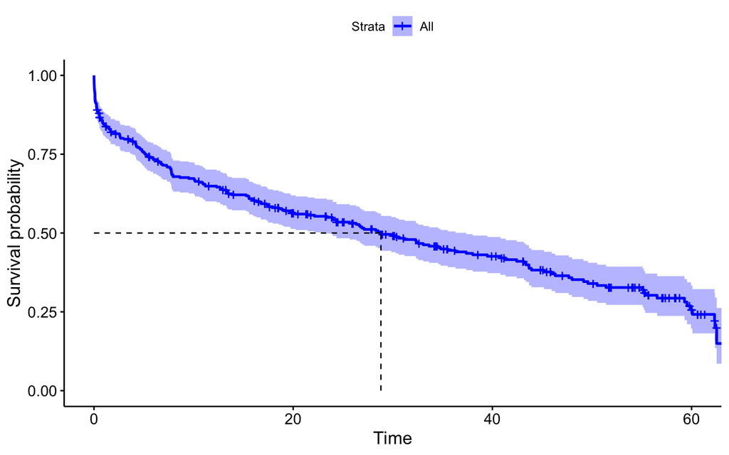

```r
ggsurvplot(mod_surv,
           data = got_surv,
           surv.median.line = "hv",
           palette = "blue")
```

You can extract the data.frame from the model with `broom::tidy()`.

```r
mod_surv %>%
  broom::tidy()
```

```
# A tibble: 291 × 8
    time n.risk n.event n.censor estimate std.error conf.high conf.low
   <dbl>  <dbl>   <dbl>    <dbl>    <dbl>     <dbl>     <dbl>    <dbl>
 1  0       359       5        0    0.986   0.00627     0.998    0.974
 2  0.01    354       4        0    0.975   0.00846     0.991    0.959
 3  0.02    350       3        0    0.967   0.00981     0.985    0.948
 4  0.03    347       3        0    0.958   0.0110      0.979    0.938
 5  0.04    344       1        0    0.955   0.0114      0.977    0.934
 6  0.05    343       2        0    0.950   0.0121      0.973    0.928
 7  0.07    341       2        0    0.944   0.0128      0.968    0.921
 8  0.09    339       6        0    0.928   0.0147      0.955    0.901
 9  0.1     333       2        0    0.922   0.0154      0.950    0.895
10  0.11    331       1        0    0.919   0.0156      0.948    0.891
# … with 281 more rows
```

Then you may have more control over the plotting.

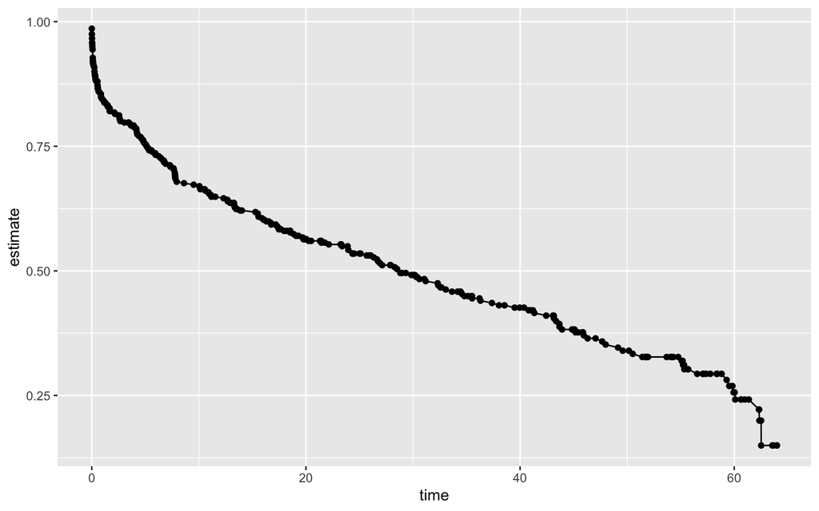

```r
mod_surv %>%
  broom::tidy() %>%
  ggplot(aes(x = time, y = estimate)) +
  geom_point() +
  geom_line()
```

And you can get info more easily.

```r
mod_surv %>%
  broom::tidy()  %>%
  filter(time < 1) %>%
  slice_max(time)
```

```
# A tibble: 1 × 8
   time n.risk n.event n.censor estimate std.error conf.high conf.low
  <dbl>  <dbl>   <dbl>    <dbl>    <dbl>     <dbl>     <dbl>    <dbl>
1  0.92    299       1        0    0.846    0.0225     0.885    0.810
```

```r
mod_surv <- survfit(Surv(exp_time_hrs, dth_flag) ~ sex,
                    data = got_surv)

summary(mod_surv)
```

```
Call: survfit(formula = Surv(exp_time_hrs, dth_flag) ~ sex, data = got_surv)

                sex=1
  time n.risk n.event survival std.err lower 95% CI upper 95% CI
  0.00    254       4    0.984 0.00781       0.9691        1.000
  0.01    250       4    0.969 0.01096       0.9473        0.990
  0.02    246       3    0.957 0.01277       0.9320        0.982
  0.03    243       2    0.949 0.01383       0.9221        0.976
  0.04    241       1    0.945 0.01432       0.9172        0.973
  0.05    240       1    0.941 0.01479       0.9124        0.970
  0.07    239       2    0.933 0.01568       0.9028        0.964
  0.09    237       6    0.909 0.01801       0.8748        0.945
  0.10    231       2    0.902 0.01869       0.8657        0.939
  0.11    229       1    0.898 0.01902       0.8611        0.936
  0.12    228       1    0.894 0.01934       0.8566        0.932
  0.14    227       1    0.890 0.01965       0.8521        0.929
  0.19    226       1    0.886 0.01995       0.8476        0.926
  0.24    225       1    0.882 0.02025       0.8431        0.922
  0.25    224       3    0.870 0.02110       0.8297        0.912
  0.28    221       1    0.866 0.02136       0.8253        0.909
  0.30    220       1    0.862 0.02163       0.8208        0.906
  0.34    218       1    0.858 0.02189       0.8164        0.902
  0.36    217       1    0.854 0.02214       0.8120        0.899
  0.43    216       1    0.850 0.02239       0.8076        0.895
  0.54    214       3    0.838 0.02311       0.7943        0.885
  0.56    211       2    0.830 0.02356       0.7856        0.878
  0.63    205       2    0.822 0.02402       0.7766        0.871
  0.74    203       1    0.818 0.02424       0.7722        0.867
  0.85    202       1    0.814 0.02446       0.7677        0.864
  0.92    201       1    0.810 0.02467       0.7633        0.860
  1.02    200       1    0.806 0.02487       0.7589        0.856
  1.14    199       1    0.802 0.02508       0.7544        0.853
  1.17    198       1    0.798 0.02528       0.7500        0.849
  1.35    195       1    0.794 0.02548       0.7456        0.846
  1.49    194       1    0.790 0.02567       0.7411        0.842
  1.66    193       1    0.786 0.02586       0.7367        0.838
  1.67    192       2    0.778 0.02623       0.7278        0.831
  2.18    189       1    0.773 0.02641       0.7234        0.827
  2.55    186       1    0.769 0.02660       0.7189        0.823
  2.59    185       2    0.761 0.02695       0.7100        0.816
```

[output cut: 135 more lines]

```
 20.25     58       1    0.692 0.04725       0.6052        0.791
 21.45     55       1    0.679 0.04803       0.5914        0.780
 23.96     49       1    0.665 0.04901       0.5760        0.769
 24.34     48       1    0.652 0.04991       0.5607        0.757
 26.34     46       1    0.637 0.05080       0.5452        0.745
 27.12     45       1    0.623 0.05161       0.5299        0.733
 32.36     40       1    0.608 0.05262       0.5128        0.720
 34.57     37       1    0.591 0.05370       0.4948        0.706
 39.49     33       1    0.573 0.05498       0.4751        0.692
 40.81     22       1    0.547 0.05833       0.4441        0.674
 41.33     21       1    0.521 0.06110       0.4142        0.656
 43.92     20       1    0.495 0.06336       0.3853        0.636
 51.42     15       1    0.462 0.06718       0.3476        0.614
 62.35      4       1    0.347 0.11203       0.1840        0.653
 62.52      3       1    0.231 0.12032       0.0833        0.641
```

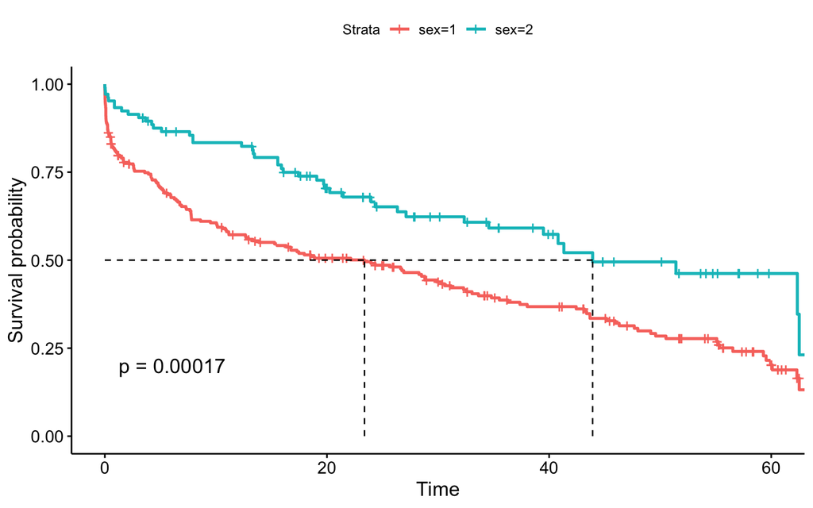

```r
ggsurvplot(mod_surv,
           data = got_surv,
           surv.median.line = "hv",
           pval = TRUE)
```

```r
mod_surv %>%
  broom::tidy()  %>%
  group_by(strata) %>%
  filter(time < 1) %>%
  slice_max(time)
```

```
# A tibble: 2 × 9
# Groups:   strata [2]
   time n.risk n.event n.censor estimate std.error conf.high conf.low strata
  <dbl>  <dbl>   <dbl>    <dbl>    <dbl>     <dbl>     <dbl>    <dbl> <chr>
1  0.92    201       1        0    0.810    0.0304     0.860    0.763 sex=1
2  0.86    100       2        0    0.933    0.0261     0.982    0.887 sex=2
```

A faster way to get a bunch of them at the same time.

```r
summary(mod_surv, times = c(1, 10, 30))
```

```
Call: survfit(formula = Surv(exp_time_hrs, dth_flag) ~ sex, data = got_surv)

                sex=1
 time n.risk n.event survival std.err lower 95% CI upper 95% CI
    1    200      48    0.810  0.0247        0.763        0.860
   10    144      49    0.606  0.0313        0.548        0.671
   30     82      36    0.438  0.0330        0.378        0.508

                sex=2
 time n.risk n.event survival std.err lower 95% CI upper 95% CI
    1     98       7    0.933  0.0243        0.887        0.982
   10     80      10    0.834  0.0369        0.765        0.909
   30     41      18    0.623  0.0516        0.530        0.733
```

The model print-out has the median survival times.

```r
mod_surv
```

```
Call: survfit(formula = Surv(exp_time_hrs, dth_flag) ~ sex, data = got_surv)

        n events median 0.95LCL 0.95UCL
sex=1 254    168   23.4    13.3    30.6
sex=2 105     44   43.9    34.6      NA
```